```python
import pandas as pd
import numpy as np
import matplotlib.pyplot as plt
import seaborn as sns
%matplotlib inline
```

```python
df = pd.read_csv('job_cleanData.csv')
df.head()
```

|  | job_ID | designation | company_id | name | work_type | involvement | employees_count | total_applicants | linkedin_followers | job_details | details_id | industry | level | City | State |
| --- | --- | --- | --- | --- | --- | --- | --- | --- | --- | --- | --- | --- | --- | --- | --- |
| 0 | 3471657636 | Data Analyst | 524 | Crossover | Remote | Full-time | 1001 | 200 | 5.395547e+06 | About the job Crossover is the world's #1 sour... | 2697 | IT Services and IT Consulting | Associate | Delhi | Delhi |
| 1 | 3471669068 | Data Analyst | 524 | Crossover | Remote | Full-time | 1001 | 184 | 5.395547e+06 | About the job Crossover is the world's #1 sour... | 2724 | IT Services and IT Consulting | Associate | New Delhi | Delhi |
| 2 | 3474349934 | Data Analyst | 2242 | Uplers | Remote | Full-time | 1001 | 200 | 9.821152e+05 | About the job Profile: ML EngineersExperience:... | 3668 | IT Services and IT Consulting | Mid-Senior level | Greater Bengaluru Area | Karnataka |
| 3 | 3472816027 | Data Analyst | 1553 | PVAR SERVICES | On-site | Full-time | 1 | 200 | 2.094000e+03 | About the job Designation: Data AnalystLocatio... | 3083 | Not Avilable | Not Avilable | Gurugram | Haryana |
| 4 | 3473311511 | Data Analyst | 2147 | Timeline Freight Brokers | On-site | Full-time | 1 | 8 | 9.821152e+05 | About the job The ideal candidate will use the... | 3359 | Not Avilable | Not Avilable | Mohali district | North West |

```python
df.describe()
```

|  | job_ID | company_id | employees_count | total_applicants | linkedin_followers | details_id |
| --- | --- | --- | --- | --- | --- | --- |
| count | 5.587000e+03 | 5587.000000 | 5587.000000 | 5587.000000 | 5.587000e+03 | 5587.000000 |
| mean | 3.467219e+09 | 1165.662431 | 2119.530517 | 24.141758 | 9.834312e+05 | 2954.158403 |
| std | 6.189089e+07 | 696.076468 | 3512.711835 | 52.756793 | 2.232506e+06 | 1687.379838 |
| min | 1.419216e+08 | 1.000000 | 1.000000 | 0.000000 | 3.000000e+00 | 1.000000 |
| 25% | 3.467374e+09 | 640.000000 | 51.000000 | 0.000000 | 1.810450e+04 | 1500.500000 |
| 50% | 3.472553e+09 | 957.000000 | 1001.000000 | 0.000000 | 4.501680e+05 | 2975.000000 |
| 75% | 3.476290e+09 | 1849.500000 | 1001.000000 | 16.000000 | 9.821152e+05 | 4422.500000 |
| max | 3.477823e+09 | 2494.000000 | 10001.000000 | 200.000000 | 1.313679e+07 | 5843.000000 |

###### Creating a new dataframe with just needed columns

```python
new_df = df.drop('job_ID', axis=1)
final_df = new_df.drop('details_id' , axis = 1)
```

```python
final_df.head()
```

|  | designation | company_id | name | work_type | involvement | employees_count | total_applicants | linkedin_followers | job_details | industry | level | City | State |
| --- | --- | --- | --- | --- | --- | --- | --- | --- | --- | --- | --- | --- | --- |
| 0 | Data Analyst | 524 | Crossover | Remote | Full-time | 1001 | 200 | 5.395547e+06 | About the job Crossover is the world's #1 sour... | IT Services and IT Consulting | Associate | Delhi | Delhi |
| 1 | Data Analyst | 524 | Crossover | Remote | Full-time | 1001 | 184 | 5.395547e+06 | About the job Crossover is the world's #1 sour... | IT Services and IT Consulting | Associate | New Delhi | Delhi |
| 2 | Data Analyst | 2242 | Uplers | Remote | Full-time | 1001 | 200 | 9.821152e+05 | About the job Profile: ML EngineersExperience:... | IT Services and IT Consulting | Mid-Senior level | Greater Bengaluru Area | Karnataka |
| 3 | Data Analyst | 1553 | PVAR SERVICES | On-site | Full-time | 1 | 200 | 2.094000e+03 | About the job Designation: Data AnalystLocatio... | Not Avilable | Not Avilable | Gurugram | Haryana |
| 4 | Data Analyst | 2147 | Timeline Freight Brokers | On-site | Full-time | 1 | 8 | 9.821152e+05 | About the job The ideal candidate will use the... | Not Avilable | Not Avilable | Mohali district | North West |

```python
final_df.info()
```

```
<class 'pandas.core.frame.DataFrame'>
RangeIndex: 5587 entries, 0 to 5586
Data columns (total 13 columns):
 #   Column              Non-Null Count  Dtype
---  ------              --------------  -----
 0   designation         5587 non-null   object
 1   company_id          5587 non-null   int64
 2   name                5587 non-null   object
 3   work_type           5587 non-null   object
 4   involvement         5587 non-null   object
 5   employees_count     5587 non-null   int64
 6   total_applicants    5587 non-null   int64
 7   linkedin_followers  5587 non-null   float64
 8   job_details         5587 non-null   object
 9   industry            5587 non-null   object
 10  level               5587 non-null   object
 11  City                5587 non-null   object
 12  State               5587 non-null   object
dtypes: float64(1), int64(3), object(9)
memory usage: 567.6+ KB
```

##### Listing the number of unique attributes present in each column

```python
for i in final_df.columns:
    print(f'{i} =  {final_df[i].nunique()}')
```

```
designation =  84
company_id =  2321
name =  2321
work_type =  3
involvement =  7
employees_count =  8
total_applicants =  190
linkedin_followers =  2938
job_details =  4349
industry =  103
level =  7
City =  123
State =  27
```

## Work type column has 3 unique category onsite, Remote, Hybrid

#### we can observe that the count of onsite and remote jobs is almost the same, but onsite is slightly higher

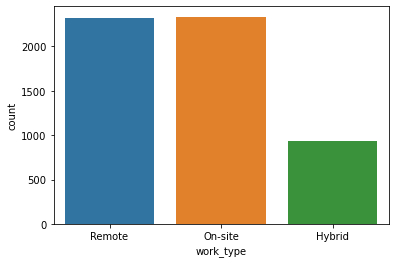

```python
ax = sns.countplot(x='work_type',data=final_df)
plt.show()
```

#### 1.FullTime 2.contract 3.internship 4.associate 5.volunteer

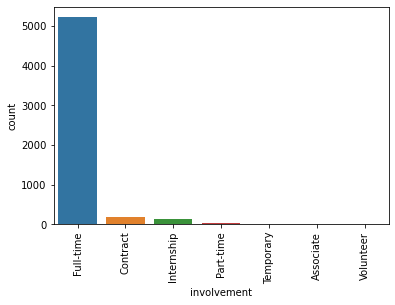

```python
sns.countplot(x='involvement',data=final_df)
plt.xticks(rotation=90)
plt.show()
```

## Level of entry for the job has unique categories

### 1.Associate 2.Mid-Senior level 3.Not Available 4.Entry level 5.Director 6.Executive 7.Internship.

#### from figure we can observe that MID SENIOR LEVEL has highest oppurtunity where as director executive and internship levels are very low .

#### we can also see that there is a lot of not available information .

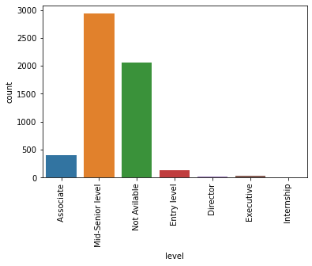

```python
sns.countplot(x='level',data=final_df)
plt.xticks(rotation=90)
plt.show()
```

### Designations plot

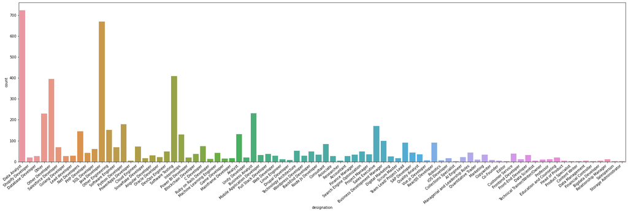

```python
fig, ax = plt.subplots()
fig.set_size_inches(30.7, 8.27)
ax = sns.countplot(x='designation',data=final_df)
ax.set_xticklabels(ax.get_xticklabels(), rotation=40, ha="right")
plt.show()
```

### listing just the top 10 designations

#### from the figure we can conclude that DATA ANALYST dominates the job openings available followed by JAVA DEVELOPER

```python
top10_designation = final_df.designation.value_counts().nlargest(10).index
top10_designation
```

```
Index(['Data Analyst', 'Java Developer', 'Software Testing', 'Other Developer',
       'Business Analyst', 'Other', 'Python Developer', 'Sales Executive',
       'Other Engineering', '.Net Developers'],
      dtype='object')
```

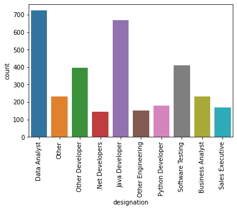

```python
top10_design = final_df[final_df.designation.isin(top10_designation)]

sns.countplot(x=top10_design.designation)

plt.xticks(rotation=90)
plt.show()
```

## Finding the top 10 industries with highest percentage of job openings

#### we can observe that IT SERVICES AND IT CONSULTING DOMINATES.

```python
top10_industry = final_df.industry.value_counts().nlargest(10).index
top10_industry
```

```
Index([' IT Services and IT Consulting', 'Not Avilable',
       ' Software Development', ' Information Technology & Services',
       ' Technology Information and Internet', ' Financial Services',
       ' Staffing and Recruiting', ' Business Consulting and Services',
       ' Human Resources Services', ' Information Services'],
      dtype='object')
```

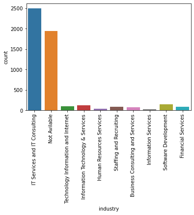

```python
top10_indus = final_df[final_df.industry.isin(top10_industry)]

sns.countplot(x=top10_indus.industry)
plt.xticks(rotation=90)
plt.show()
```

## Finding out the top 10 cities in which job openings are high

### as expected BENGALURU has the highest job openings

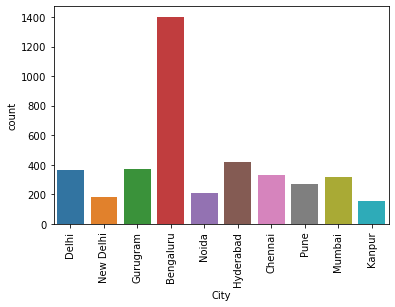

```python
top10_city = final_df.City.value_counts().nlargest(10).index

top10_cit = final_df[final_df.City.isin(top10_city)]

sns.countplot(x=top10_cit.City)
plt.xticks(rotation=90)
plt.show()
```

### KDE plot for employee count

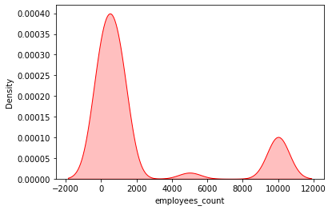

```python
sns.kdeplot(x=final_df['employees_count'], fill=True, color='r')
```

### KDE plot for total applicants

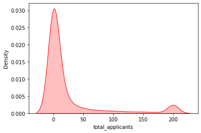

```python
sns.kdeplot(x=final_df['total_applicants'], fill=True, color='r')
```

### KDE plot for linkedin followers

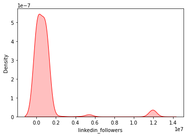

```python
sns.kdeplot(x=final_df['linkedin_followers'], fill=True, color='r')
```

### From the following figure we can observe that maximun employees are from odisha

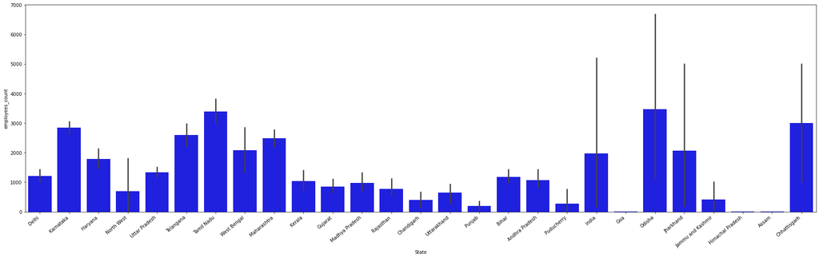

```python
fig, ax = plt.subplots()
fig.set_size_inches(30.7, 8.27)
sns.barplot(x="State", y="employees_count", data=final_df,
            label="famous_industry_ineachstate", color="b")
ax.set_xticklabels(ax.get_xticklabels(), rotation=40, ha="right")
plt.show()
```

### From the following plot we can conclude that maximun applicants are from chhattisgarh

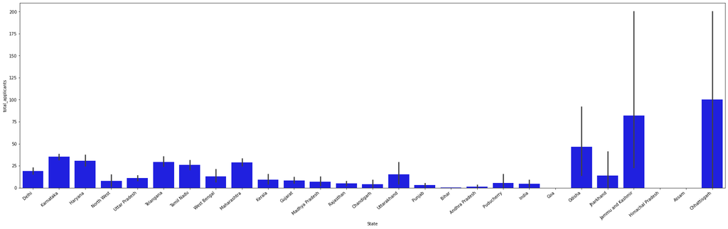

```python
fig, ax = plt.subplots()
fig.set_size_inches(30.7, 8.27)
sns.barplot(x="State", y="total_applicants", data=final_df,
            label="famous_industry_ineachstate", color="b")
ax.set_xticklabels(ax.get_xticklabels(), rotation=40, ha="right")
plt.show()
```

## The figure below is a cross table plot

### KEY FINDINGS:

#### 1.Data Analyst have highest hybrid type job openings and they have comparitively less remote jobs

#### 2.Java developer have highest remote job oppurtunities followed by software testing

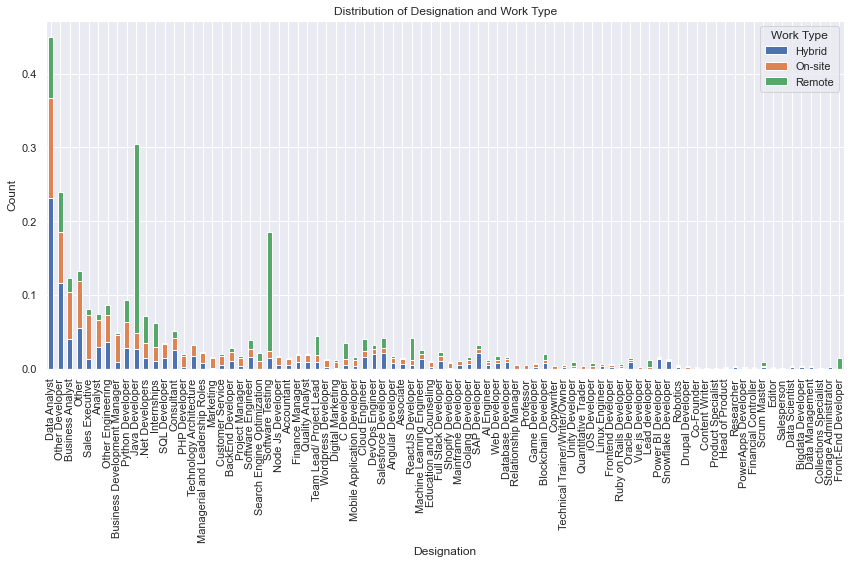

```python
cross_table = pd.crosstab(final_df['designation'], final_df['work_type'], normalize='columns')

cross_table = cross_table.sort_values(by='On-site', ascending=False)

sns.set(style='darkgrid')
fig, ax = plt.subplots(figsize=(12, 8))

cross_table.plot(kind='bar', stacked=True, ax=ax)

ax.set_title('Distribution of Designation and Work Type')
ax.set_xlabel('Designation')
ax.set_ylabel('Count')

ax.legend(title='Work Type')

plt.tight_layout()

plt.show()
```

### Top 10 designations for each work type

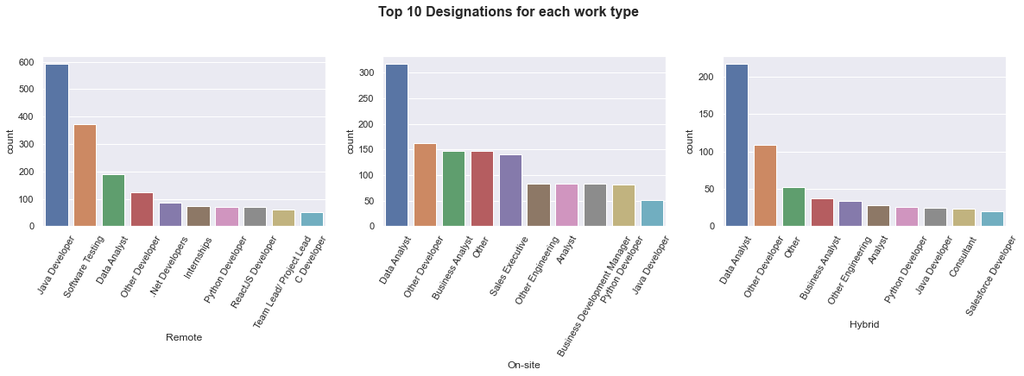

```python
wt = final_df.work_type.unique()
co=1
plt.figure(figsize=(20,8))
plt.suptitle('Top 10 Designations for each work type',fontsize=16, fontweight='bold')
for i in wt:
    plt.subplot(2,3,co)
    pl = final_df[final_df['work_type'] == i]['designation'].value_counts().nlargest(10).index
    pl_filter = final_df[final_df['work_type'] == i]
    sns.countplot(data=pl_filter, x='designation', order=pl)
    plt.xlabel(i)
    plt.xticks(rotation=60)

    co+=1


plt.show()
```

### Top 10 designations for each level

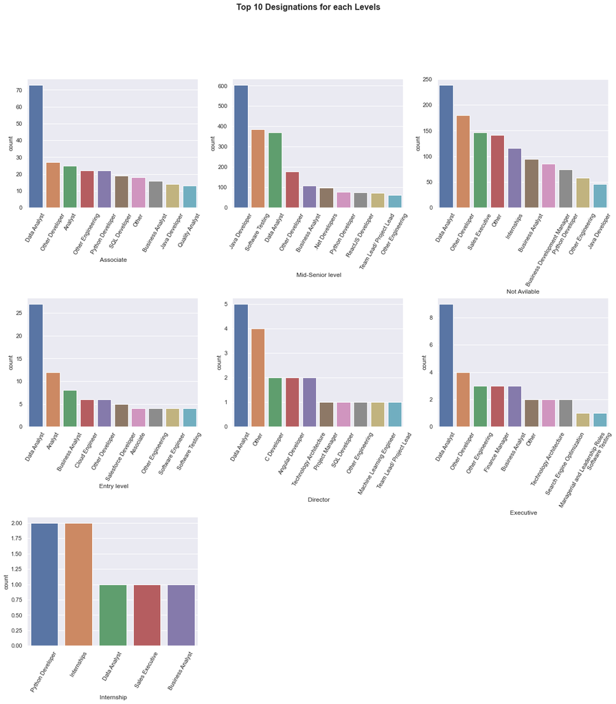

```python
wt = final_df.level.unique()
co = 1

plt.figure(figsize=(20,20 ))
plt.suptitle('Top 10 Designations for each Levels', fontsize=16, fontweight='bold')

for i in wt:
    plt.subplot(3, 3, co)
    plt.subplots_adjust(hspace=0.7)

    pl = final_df[final_df['level'] == i]['designation'].value_counts().nlargest(10).index
    pl_filter = final_df[final_df['level'] == i]

    sns.countplot(data=pl_filter, x='designation',  order=pl)
    plt.xlabel(i)
    plt.xticks(rotation=60)

    co += 1


plt.show()
```

### Top 10 companies for each level

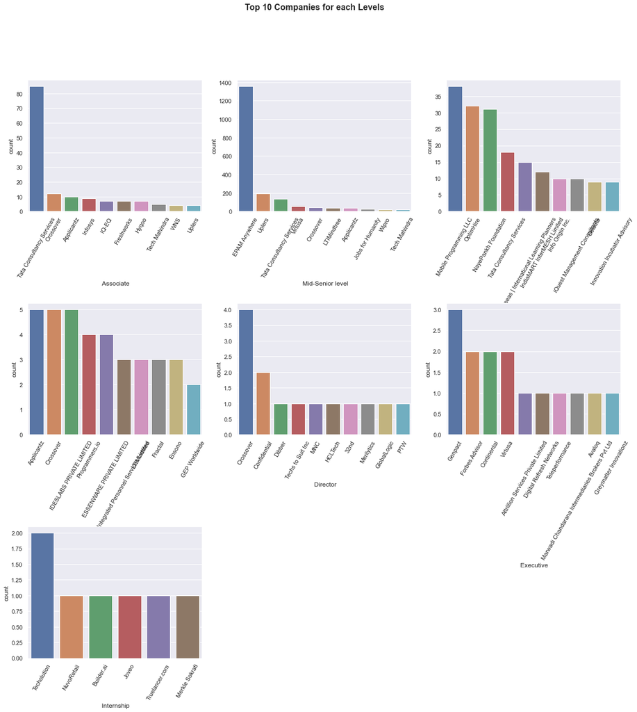

```python
wt = final_df.level.unique()
co = 1

plt.figure(figsize=(20,20 ))
plt.suptitle('Top 10 Companies for each Levels', fontsize=16, fontweight='bold')

for i in wt:
    plt.subplot(3, 3, co)
    plt.subplots_adjust(hspace=0.7)

    pl = final_df[final_df['level'] == i]['name'].value_counts().nlargest(10).index
    pl_filter = final_df[final_df['level'] == i]

    sns.countplot(data=pl_filter, x='name',  order=pl)
    plt.xlabel(i)
    plt.xticks(rotation=60)

    co += 1


plt.show()
```

###### In conclusion TCS provides highest associate level entry and EPAM Anywhere provides highest in mid senior level

### Top 10 companies for each worktype

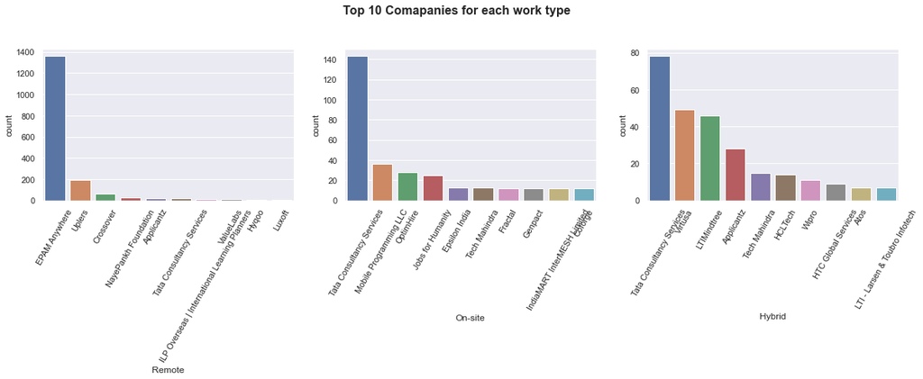

```python
wt = final_df.work_type.unique()
co=1
plt.figure(figsize=(20,8))
plt.suptitle('Top 10 Comapanies for each work type',fontsize=16, fontweight='bold')
for i in wt:
    plt.subplot(2,3,co)
    pl = final_df[final_df['work_type'] == i]['name'].value_counts().nlargest(10).index
    pl_filter = final_df[final_df['work_type'] == i]
    sns.countplot(data=pl_filter, x='name', order=pl)
    plt.xlabel(i)
    plt.xticks(rotation=60)

    co+=1


plt.show()
```

###### In conclusion EPAM Anywhere provides highest Remote level jobs and TCS provides highest On-Site and Hybrid Level jobs